# Using eisaR for Exon-Intron Split Analysis (EISA)

Michael Stadler

2019-11-07

# 1 Introduction

Exon-Intron Split Analysis has been described in (Gaidatzis et al. 2015). It consists of separately quantifying exonic and intronic alignments in RNA-seq data, in order to measure changes in mature RNA and pre-mRNA reads across different experimental conditions. We have shown that this allows quantification of transcriptional and post-transcriptional regulation of gene expression.

The `eisaR` package contains convenience functions to facilitate the steps in an exon-intron split analysis, which consists of:  
1. preparing the annotation (exonic and gene body coordinate ranges)  
2. quantifying RNA-seq alignments in exons and introns  
3. calculating and comparing exonic and intronic changes across conditions  
4. visualizing the results

For the steps 1. and 2. above, this vignette makes use of Bioconductor annotation and the *QuasR* package. It is also possible to obtain count tables for exons and introns using some other pipeline or approach, and directly start with step 3.

# 2 Preparing the annotation

As mentioned, `eisaR` uses gene annotations from Bioconductor. They are provided in the form of `TxDb` objects, e.g. via packages such as *TxDb.Mmusculus.UCSC.mm10.knownGene*. You can see available annotations using the following code:

```r
pkgs <- BiocManager::available("TxDb")
```

If you would like to use an alternative source of gene annotations, you might still be able to use `eisaR` by first converting your annotations into a `TxDb` (see `makeTxDb` in the *GenomicFeatures* package).

For this example, `eisaR` contains a small `TxDb` to illustrate how regions are extracted. We will load it from a file. Alternatively, the object would be loaded using `library(...)`, for example using `library(TxDb.Mmusculus.UCSC.mm10.knownGene)`.

```r
# load package
library(eisaR)

# get TxDb object
txdbFile <- system.file("extdata", "hg19sub.sqlite", package = "eisaR")
txdb <- AnnotationDbi::loadDb(txdbFile)
```

Exon and gene body regions are then extracted from the `TxDb`:

```r
# extract filtered exonic and gene body regions
regS <- getRegionsFromTxDb(txdb = txdb, strandedData = TRUE)
```

```
#> extracting exon coordinates
#> total number of genes/exons: 12/32
#> removing overlapping/single-exon/ambiguous genes (8)
#> creating filtered regions for 4 genes (33.3%) with 20 exons (62.5%)
```

```r
regU <- getRegionsFromTxDb(txdb = txdb, strandedData = FALSE)
```

```
#> extracting exon coordinates
#> total number of genes/exons: 12/32
#> removing overlapping/single-exon/ambiguous genes (9)
#> creating filtered regions for 3 genes (25%) with 17 exons (53.1%)
```

```r
lengths(regS)
```

```
#>      exons genebodies
#>         20          4
```

```r
lengths(regU)
```

```
#>      exons genebodies
#>         17          3
```

```r
regS$exons
```

```
#> GRanges object with 20 ranges and 0 metadata columns:
#>                   seqnames      ranges strand
#>                      <Rle>   <IRanges>  <Rle>
#>   ENSG00000078808     chr1 17278-18194      -
#>   ENSG00000078808     chr1 18828-21741      -
#>   ENSG00000078808     chr1 23614-23747      -
#>   ENSG00000078808     chr1 24202-24358      -
#>   ENSG00000078808     chr1 27799-27854      -
#>               ...      ...         ...    ...
#>   ENSG00000186891     chr1   5740-6070      -
#>   ENSG00000186891     chr1   6755-7081      -
#>   ENSG00000254999     chr3   2266-2513      +
#>   ENSG00000254999     chr3 12300-12402      +
#>   ENSG00000254999     chr3 12943-13884      +
#>   -------
#>   seqinfo: 3 sequences from an unspecified genome
```

As you can see, the filtering procedure removes slightly more genes for unstranded data (`strandedData = FALSE`), as overlapping genes cannot be discriminated even if they reside on opposite strands.

You can also export the obtained regions into files. This may be useful if you plan to align and/or quantify reads outside of R. For example, you can use *rtracklayer* to export the regions in `regS` into `.gtf` files:

```r
library(rtracklayer)
export(regS$exons, "hg19sub_exons_stranded.gtf")
export(regS$genebodies, "hg19sub_genebodies_stranded.gtf")
```

# 3 Quantify RNA-seq alignments in exons and introns

For this example we will use the *QuasR* package for indexing and alignment of short reads, and a small RNA-seq dataset that is contained in that package. As mentioned, it is also possible to align or also quantify your reads using an alternative aligner/counter, and skip over these steps.

## 3.1 Align reads

Let’s first copy the sample data from the *QuasR* package to the current working directory, all contained in a folder named `extdata`:

```r
library(QuasR)
file.copy(system.file(package = "QuasR", "extdata"), ".", recursive = TRUE)
```

```
#> [1] TRUE
```

We next align the reads to a mini-genome (fasta file `extdata/hg19sub.fa`) using `qAlign`:

```r
sampleFile <- "extdata/samples_chip_single.txt"
genomeFile <- "extdata/hg19sub.fa"

proj <- qAlign("extdata/samples_rna_single.txt", "extdata/hg19sub.fa",
               splicedAlignment = TRUE)
```

```
#> Creating .fai file for: /tungstenfs/groups/gbioinfo/stadler/development/R/compbio-eisaR/vignettes/extdata/hg19sub.fa
#> alignment files missing - need to:
#>     create alignment index for the genome
#>     create 4 genomic alignment(s)
#> Creating an Rbowtie index for /tungstenfs/groups/gbioinfo/stadler/development/R/compbio-eisaR/vignettes/extdata/hg19sub.fa
#> Finished creating index
#> Testing the compute nodes...OK
#> Loading QuasR on the compute nodes...OK
#> Available cores:
#> xenon6.fmi.ch: 1
#> Performing genomic alignments for 4 samples. See progress in the log file:
#> /tungstenfs/groups/gbioinfo/stadler/development/R/compbio-eisaR/vignettes/QuasR_log_205cc6582fdb5.txt
#> Genomic alignments have been created successfully
```

```r
alignmentStats(proj)
```

```
#>                seqlength mapped unmapped
#> Sample1:genome     95000   6003        1
#> Sample2:genome     95000   6000        0
```

## 3.2 Count alignments in exons and gene bodies

Alignments in exons and gene bodies can now be counted using `qCount` and the `regU` that we have generated earlier (assuming that the data is unstranded). Intronic counts can then be obtained from the difference between gene bodies and exons:

```r
cntEx <- qCount(proj, regU$exons, orientation = "any")
```

```
#> counting alignments...done
#> collapsing counts by sample...done
#> collapsing counts by query name...done
```

```r
cntGb <- qCount(proj, regU$genebodies, orientation = "any")
```

```
#> counting alignments...done
#> collapsing counts by sample...done
```

```r
cntIn <- cntGb - cntEx
head(cntEx)
```

```
#>                 width Sample1 Sample2
#> ENSG00000078808  4837     711    1088
#> ENSG00000186827  1821      37       8
#> ENSG00000186891  1470      26       2
```

```r
head(cntIn)
```

```
#>                 width Sample1 Sample2
#> ENSG00000078808 10307       5      16
#> ENSG00000186827  1012       3       0
#> ENSG00000186891  1734       4       0
```

As mentioned, both alignments and counts can also be obtained using alternative approaches. It is required that the two resulting exon and intron count tables have identical structure (genes in rows, samples in columns, the same order of rows and columns in both tables).

## 3.3 Load full count tables

The above example only contains very few genes. For the rest of the vignette, we will use count tables from a real RNA-seq experiment that are provided in the `eisaR` package. The counts correspond to the rawdata used in Figure 3a of (Gaidatzis et al. 2015) and are also available online from the [supplementary material](https://fmicompbio.github.io/projects/EISA/EISA.html):

```r
cntEx <- readRDS(system.file("extdata",
                             "Fig3abc_GSE33252_rawcounts_exonic.rds",
                             package = "eisaR"))
cntIn <- readRDS(system.file("extdata",
                             "Fig3abc_GSE33252_rawcounts_intronic.rds",
                             package = "eisaR"))
```

# 4 Run EISA conveniently

All the further steps in exon-intron split analysis can now be performed using a single function `runEISA`. If you prefer to perform the analysis step-by-step, you can skip now to section 6.

```r
# remove "width" column
Rex <- cntEx[, colnames(cntEx) != "width"]
Rin <- cntIn[, colnames(cntIn) != "width"]

# create condition factor (contrast will be TN - ES)
cond <- factor(c("ES", "ES", "TN", "TN"))

# run EISA
res <- runEISA(Rex, Rin, cond)
```

```
#> filtering quantifyable genes...keeping 8481 from 20288 (41.8%)
#> fitting statistical model...done
#> calculating contrasts...done
```

## 4.1 Two alternative implementations of EISA

Using the argument `method`, you can choose between two alternative implementations of EISA. `method="published"` will use an implementation that corresponds to the algorithm described in (Gaidatzis et al. 2015). `method="new"` will use more of the functionality provided by `edgeR` (e.g. for normalization and effect size calculation), summarized in the table below:

| Aspect: | `method="published"` | `method="new"` |
| --- | --- | --- |
| normalization | linear scaling to the mean library size | `edgeR::calcNormFactors` |
| gene selection | log2(x + 8) > 5 (in both exons and introns) | cpm > 5 in at least 2 samples (exons or introns) |
| effect size | log2((x + 8)/(y + 8)) | `edgeR::predFC` |
| model fit | `edgeR::glmFit` | `edgeR::glmQLFit` |
| significance test | `edgeR::glmLRT` | `edgeR::glmQLFTest` |

While both methods yield highly similar results, `method="new"` is often less stringent when selecting quantifyable genes, but more stringent when calling significant changes (especially with low numbers of replicates).

Here is an illustration of how the results differ between the two:

```r
res1 <- runEISA(Rex, Rin, cond, method = "published")
```

```
#> filtering quantifyable genes...keeping 8481 from 20288 (41.8%)
#> fitting statistical model...done
#> calculating contrasts...done
```

```r
res2 <- runEISA(Rex, Rin, cond, method = "new")
```

```
#> filtering quantifyable genes...keeping 12576 from 20288 (62%)
#> fitting statistical model...done
#> calculating contrasts...done
```

```r
# number of quantifyable genes
nrow(res1$DGEList)
```

```
#> [1] 8481
```

```r
nrow(res2$DGEList)
```

```
#> [1] 12576
```

```r
# number of genes with significant post-transcriptional regulation
sum(res1$tab.ExIn$FDR < 0.05)
```

```
#> [1] 490
```

```r
sum(res2$tab.ExIn$FDR < 0.05)
```

```
#> [1] 117
```

```r
# comparison of deltas
ids <- intersect(rownames(res1$DGEList), rownames(res2$DGEList))
cor(res1$contrasts[ids,"Dex"], res2$contrasts[ids,"Dex"])
```

```
#> [1] 0.9991963
```

```r
cor(res1$contrasts[ids,"Din"], res2$contrasts[ids,"Din"])
```

```
#> [1] 0.9979985
```

```r
cor(res1$contrasts[ids,"Dex.Din"], res2$contrasts[ids,"Dex.Din"])
```

```
#> [1] 0.9779875
```

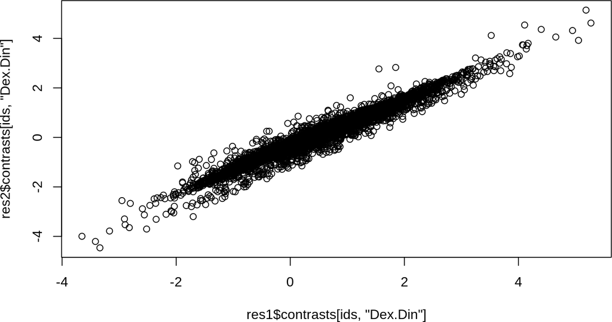

```r
plot(res1$contrasts[ids,"Dex.Din"], res2$contrasts[ids,"Dex.Din"])
```

# 5 Visualize EISA results

We can now visualize the results by plotting intronic changes versus exonic changes (genes with signficant interactions, which are likely to be post-transcriptionally regulated, are color coded):

```
#> identified 490 genes to highlight
```

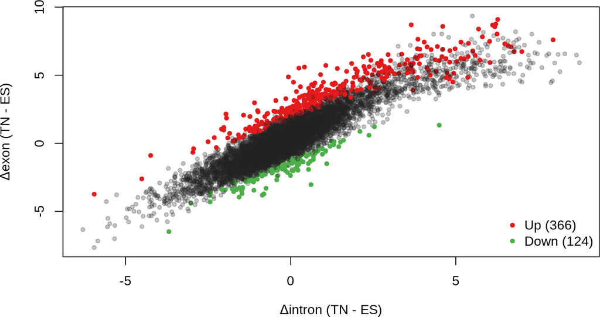

```r
plotEISA(res, contrast = "ExIn")
```

```
#> identified 5430 genes to highlight
```

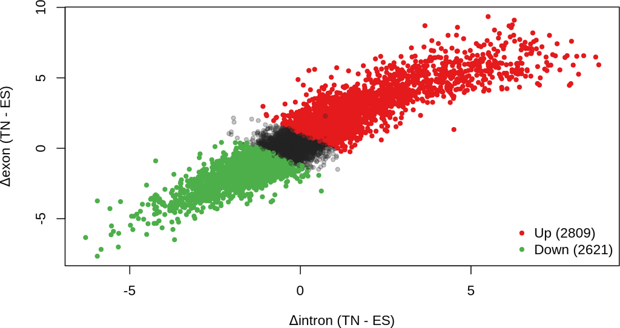

```r
plotEISA(res, contrast = "cond")
```

# 6 Run EISA step-by-step

As an alternative to `runEISA` (section 4) and `plotEISA` (section 5) described above, you can also analyse the data step-by-step as described in (Gaidatzis et al. 2015). This may be preferrable to understand each individual step and be able to access intermediate results.

The results obtained in this way are identical to what you get with `runEISA(..., method = "published")`, so if you are happy with `runEISA` you can skip the rest of the vignette.

## 6.1 Normalization

Normalization is performed separately on exonic and intronic counts, assuming that varying exon over intron ratios between samples are of technical origin.

```r
# remove column "width"
Rex <- cntEx[,colnames(cntEx) != "width"]
Rin <- cntIn[,colnames(cntIn) != "width"]
Rall <- Rex + Rin
fracIn <- colSums(Rin)/colSums(Rall)
summary(fracIn)
```

```
#>    Min. 1st Qu.  Median    Mean 3rd Qu.    Max.
#>  0.2696  0.2977  0.3105  0.3459  0.3587  0.4929
```

```r
# scale counts to the mean library size,
# separately for exons and introns
Nex <- t(t(Rex) / colSums(Rex) * mean(colSums(Rex)))
Nin <- t(t(Rin) / colSums(Rin) * mean(colSums(Rin)))

# log transform (add a pseudocount of 8)
NLex <- log2(Nex + 8)
NLin <- log2(Nin + 8)
```

## 6.2 Identify quantifyable genes

Genes with very low counts in either exons or introns are better removed, as they will be too noisy to yield useful results. We use here a fixed cut-off on the normalized, log-transformed intron and exonic counts:

```r
quantGenes <- rownames(Rex)[ rowMeans(NLex) > 5.0 & rowMeans(NLin) > 5.0 ]
length(quantGenes)
```

```
#> [1] 8481
```

## 6.3 Calculate $\Delta I$, $\Delta E$ and $\Delta E - \Delta I$

The count tables were obtained from a total RNA-seq experiments in mouse embryonic stem (MmES) cells and derived terminal neurons (MmTN), with two replicates for each condition.

We will now calculate the changes between neurons and ES cells in introns ($\Delta I$), in exons ($\Delta E$), and the difference between the two ($\Delta E - \Delta I$):

```r
Dex <- NLex[,c("MmTN_RNA_total_a","MmTN_RNA_total_b")] - NLex[,c("MmES_RNA_total_a","MmES_RNA_total_b")]
Din <- NLin[,c("MmTN_RNA_total_a","MmTN_RNA_total_b")] - NLin[,c("MmES_RNA_total_a","MmES_RNA_total_b")]
Dex.Din <- Dex - Din

cor(Dex[quantGenes,1], Dex[quantGenes,2])
```

```
#> [1] 0.9379397
```

```r
cor(Din[quantGenes,1], Din[quantGenes,2])
```

```
#> [1] 0.8449252
```

```r
cor(Dex.Din[quantGenes,1], Dex.Din[quantGenes,2])
```

```
#> [1] 0.5518187
```

Both exonic and intronic changes are correlated across replicates, and so are the differences, indicating a reproducible signal for post-transcriptional regulation.

## 6.4 Statistical analysis

Finally, we use the replicate measurement in the *edgeR* framework to calculate the significance of the changes:

```r
# create DGEList object with exonic and intronic counts
library(edgeR)
cnt <- data.frame(Ex = Rex, In = Rin)
y <- DGEList(counts = cnt, genes = data.frame(ENTREZID = rownames(cnt)))

# select quantifyable genes and normalize
y <- y[quantGenes, ]
y <- calcNormFactors(y)

# design matrix with interaction term
region <- factor(c("ex","ex","ex","ex","in","in","in","in"), levels = c("in", "ex"))
cond <- rep(factor(c("ES","ES","TN","TN")), 2)
design <- model.matrix(~ region * cond)
rownames(design) <- colnames(cnt)
design
```

```
#>                     (Intercept) regionex condTN regionex:condTN
#> Ex.MmES_RNA_total_a           1        1      0               0
#> Ex.MmES_RNA_total_b           1        1      0               0
#> Ex.MmTN_RNA_total_a           1        1      1               1
#> Ex.MmTN_RNA_total_b           1        1      1               1
#> In.MmES_RNA_total_a           1        0      0               0
#> In.MmES_RNA_total_b           1        0      0               0
#> In.MmTN_RNA_total_a           1        0      1               0
#> In.MmTN_RNA_total_b           1        0      1               0
#> attr(,"assign")
#> [1] 0 1 2 3
#> attr(,"contrasts")
#> attr(,"contrasts")$region
#> [1] "contr.treatment"
#>
#> attr(,"contrasts")$cond
#> [1] "contr.treatment"
```

```r
# estimate model parameters
y <- estimateDisp(y, design)
fit <- glmFit(y, design)

# calculate likelihood-ratio between full and reduced models
lrt <- glmLRT(fit)

# create results table
tt <- topTags(lrt, n = nrow(y), sort.by = "none")
head(tt$table[order(tt$table$FDR, decreasing = FALSE), ])
```

```
#>        ENTREZID    logFC   logCPM       LR       PValue          FDR
#> 14680     14680 6.375699 6.554051 95.79494 1.274210e-22 1.080658e-18
#> 75209     75209 5.341413 6.400361 85.66167 2.135122e-20 9.053983e-17
#> 268354   268354 9.854778 8.402066 53.71350 2.319637e-13 6.557614e-10
#> 17957     17957 4.342644 6.864176 51.63948 6.668718e-13 1.413935e-09
#> 93765     93765 3.849670 6.603142 51.08555 8.842689e-13 1.499897e-09
#> 68666     68666 4.536512 5.872792 48.29846 3.660400e-12 5.173976e-09
```